# 326.212 Final Project: Part 3 - Q2

## 2020-10451 Baek Dae Hyun

## Part 3 - Q2

### Step 1

## [문제]

```r
##1##

w2017<-read.csv("./data/weather2017.csv")
w2018<-read.csv("./data/weather2018.csv")
w2019<-read.csv("./data/weather2019.csv")
x<-rbind(w2017,w2018,w2019)%>%
  rename("Station code"=1,"District"=2,"Measurement date"=3,"Temper"=4,"Direct"=5,"Speed"=6)
head(x)
```

```
##   Station code District Measurement date Temper Direct Speed
## 1          400     강남 2017-01-01 00:00    1.7   68.1   1.3
## 2          400     강남 2017-01-01 01:00    1.4   69.1   1.3
## 3          400     강남 2017-01-01 02:00    1.2   66.2   1.6
## 4          400     강남 2017-01-01 03:00    0.5   66.0   1.5
## 5          400     강남 2017-01-01 04:00    0.6   63.4   0.5
## 6          400     강남 2017-01-01 05:00    0.4   63.2   0.8
```

rbind와 rename을 통해 문제 조건에 맞는 데이터 x를 생성하였다.

```r
##2##

w2017jo<-read.csv("./data/weather2017(Jongno).csv")
w2018jo<-read.csv("./data/weather2018(Jongno).csv")
w2019jo<-read.csv("./data/weather2019(Jongno).csv")
y<-rbind(w2017jo,w2018jo,w2019jo)%>%
  rename("Station code"=1,"District"=2,"Measurement date"=3,"Temper"=4,"Speed"=5,"Direct"=6)

head(y)
```

```
##   Station code District Measurement date Temper Speed Direct
## 1          108     서울 2017-01-01 00:00    0.2   2.2     20
## 2          108     서울 2017-01-01 01:00    0.0   1.4     20
## 3          108     서울 2017-01-01 02:00   -0.3   1.9     50
## 4          108     서울 2017-01-01 03:00   -0.7   2.0     50
## 5          108     서울 2017-01-01 04:00   -1.1   1.6     20
## 6          108     서울 2017-01-01 05:00   -1.4   1.4     50
```

rbind와 rename을 통해 문제 조건에 맞는 데이터 y를 생성하였다.

```r
##3##
z<-rbind(x,y)
head(z)
```

```
##   Station code District Measurement date Temper Direct Speed
## 1          400     강남 2017-01-01 00:00    1.7   68.1   1.3
## 2          400     강남 2017-01-01 01:00    1.4   69.1   1.3
## 3          400     강남 2017-01-01 02:00    1.2   66.2   1.6
## 4          400     강남 2017-01-01 03:00    0.5   66.0   1.5
## 5          400     강남 2017-01-01 04:00    0.6   63.4   0.5
## 6          400     강남 2017-01-01 05:00    0.4   63.2   0.8
```

1과 2에서 만든 x, y를 rbind하여 문제 조건에 맞는 데이터 z를 생성하였다.

```r
##4##
kma<-read.csv("./data/kmacode.csv")

z0<-z%>%
  rename(Station.code=`Station code`)%>%
  full_join(kma,by="Station.code")%>%
  rename(District=District.y)%>%
  dplyr::select(-District.x,-Station.code)

head(z0)
```

```
##   Measurement date Temper Direct Speed   District
## 1 2017-01-01 00:00    1.7   68.1   1.3 Gangnam-gu
## 2 2017-01-01 01:00    1.4   69.1   1.3 Gangnam-gu
## 3 2017-01-01 02:00    1.2   66.2   1.6 Gangnam-gu
## 4 2017-01-01 03:00    0.5   66.0   1.5 Gangnam-gu
## 5 2017-01-01 04:00    0.6   63.4   0.5 Gangnam-gu
## 6 2017-01-01 05:00    0.4   63.2   0.8 Gangnam-gu
```

kma와 z는 station code를 key로 활용하였을 때 결합될 수 있다. 따라서 z의 변수명을 kma의 것과 같이 Station.code로 바꾸고 kma와 그 key로 결합한 뒤, kma에 들어있는 지역구의 영어이름을 District로 저장, 나머지 불필요한 열들은 모두 제거하여 최종적으로 기존 데이터의 지역구만 영어로 바뀐 데이터셋 z0를 만든다.

```r
##5##
z1<-data_part2q4%>%
  dplyr::select(Measurement.date,Station.name.district.,Item.name,Average.value)%>%
  tidyr::spread(key="Item.name",value="Average.value")%>%
rename(District=Station.name.district.,"Measurement date"=Measurement.date)

head(z1)
```

```
##   Measurement date      District  CO   NO2    O3 PM10 PM2.5   SO2
## 1 2017-01-01 00:00     Dobong-gu 0.9 0.051 0.002   81    40 0.006
## 2 2017-01-01 00:00 Dongdaemun-gu 1.1 0.052 0.002   76    50 0.006
## 3 2017-01-01 00:00    Dongjak-gu 1.2 0.062 0.002   63    49 0.006
## 4 2017-01-01 00:00  Eunpyeong-gu 0.6 0.045 0.003   73    46 0.005
## 5 2017-01-01 00:00    Gangbuk-gu 1.2 0.046 0.001   63    51 0.004
## 6 2017-01-01 00:00   Gangdong-gu 0.9 0.042 0.002   68    53 0.004
```

이 문제에서는 part 2의 Q4 처리가 끝난 데이터를 사용하라고 하였는데, 이를 위해 part 2 문제 진행을 할 때 Q4가 끝난 데이터를 data_part2q4로 따로 저장해놓았다. 문제는 part 2의 Q12 문제의 spread 과정과 동일하며, key와 value 값을 item name과 average value로 한 뒤 문제 조건에 맞게 약간의 열 이름의 수정을 가하여 데이터프레임 z1을 만들었다.

```r
##6##
head(z0)
```

```
##   Measurement date Temper Direct Speed   District
## 1 2017-01-01 00:00    1.7   68.1   1.3 Gangnam-gu
## 2 2017-01-01 01:00    1.4   69.1   1.3 Gangnam-gu
## 3 2017-01-01 02:00    1.2   66.2   1.6 Gangnam-gu
## 4 2017-01-01 03:00    0.5   66.0   1.5 Gangnam-gu
## 5 2017-01-01 04:00    0.6   63.4   0.5 Gangnam-gu
## 6 2017-01-01 05:00    0.4   63.2   0.8 Gangnam-gu
```

```r
head(z1)
```

```
##   Measurement date      District  CO   NO2    O3 PM10 PM2.5   SO2
## 1 2017-01-01 00:00     Dobong-gu 0.9 0.051 0.002   81    40 0.006
## 2 2017-01-01 00:00 Dongdaemun-gu 1.1 0.052 0.002   76    50 0.006
## 3 2017-01-01 00:00    Dongjak-gu 1.2 0.062 0.002   63    49 0.006
## 4 2017-01-01 00:00  Eunpyeong-gu 0.6 0.045 0.003   73    46 0.005
## 5 2017-01-01 00:00    Gangbuk-gu 1.2 0.046 0.001   63    51 0.004
## 6 2017-01-01 00:00   Gangdong-gu 0.9 0.042 0.002   68    53 0.004
```

```r
step1<-inner_join(z0,z1,by=c("Measurement date","District"))%>%
  dplyr::select(`Measurement date`,District,CO,NO2,O3,PM10,PM2.5,SO2,Temper,Direct,Speed)
#print data that was made
head(step1)
```

```
##   Measurement date   District  CO   NO2    O3 PM10 PM2.5   SO2 Temper Direct
## 1 2017-01-01 00:00 Gangnam-gu 0.8 0.040 0.002   63    48 0.005    1.7   68.1
## 2 2017-01-01 01:00 Gangnam-gu 0.8 0.038 0.002   61    44 0.005    1.4   69.1
## 3 2017-01-01 02:00 Gangnam-gu 0.8 0.037 0.002   71    44 0.004    1.2   66.2
## 4 2017-01-01 03:00 Gangnam-gu 0.7 0.034 0.002   79    44 0.004    0.5   66.0
## 5 2017-01-01 04:00 Gangnam-gu 0.7 0.031 0.002   73    40 0.004    0.6   63.4
## 6 2017-01-01 05:00 Gangnam-gu 0.8 0.032 0.002   64    51 0.005    0.4   63.2
##   Speed
## 1   1.3
## 2   1.3
## 3   1.6
## 4   1.5
## 5   0.5
## 6   0.8
```

공통된 Measurement와 District만을 병합해야 하므로 full_join이 아닌 inner_join을 수행한 뒤, 필요한 열이 아닌 불필요하게 join된 열은 모두 제거하였다.

### Step 2

## [문제 1] 재현

```r
#1
step2_PM10<-step1[!is.na(step1),]%>%
  filter(PM10>150)%>%
  dplyr::select(Direct)
head(step2_PM10)
```

```
##    Direct
## 41  279.8
## 42  278.8
## 43  301.7
## 44  285.5
## 45  288.6
## 46  291.1
```

filter와 select를 통해 문제 조건에 맞는 데이터 step2_PM10을 생성하였다.

```r
#2
step2_PM2.5<-step1[!is.na(step1),]%>%
  filter(PM2.5>75)%>%
  dplyr::select(Direct)
head(step2_PM2.5)
```

```
##    Direct
## 14   57.8
## 15   67.1
## 38  273.7
## 39  272.4
## 40  295.9
## 41  279.8
```

```r
#3
step2_PM10<-step2_PM10%>%
  filter(!is.na(Direct),Direct>0,Direct<=360)
step2_PM2.5<-step2_PM2.5%>%
  filter(!is.na(Direct),Direct>0,Direct<=360)

head(step2_PM10)
```

```
##    Direct
## 41  279.8
## 42  278.8
## 43  301.7
## 44  285.5
## 45  288.6
## 46  291.1
```

```r
head(step2_PM2.5)
```

```
##    Direct
## 14   57.8
## 15   67.1
## 38  273.7
## 39  272.4
## 40  295.9
## 41  279.8
```

앞서 만든 2개의 데이터프레임에 똑같이 filter를 통해 문제 조건이 제시하는 범위에 속하는 Direct 값을 갖는 열만 추려내었다.

```r
#4
direction_8<-factor(c("N","NE","E","SE","S","SW","W","NW","N"))
breaks <- c(0, 360/16, (1/16 + (1:7 / 8)) * 360, 360)
#breaks = 0.0  22.5  67.5 112.5 157.5 202.5 247.5 292.5 337.5 360.0
k<-step2_PM10
l<-step2_PM2.5
step2_PM10<-step2_PM10%>%
  mutate(Direct=cut(Direct,breaks, labels=direction_8))
step2_PM2.5<-step2_PM2.5%>%
  mutate(Direct=cut(Direct,breaks, labels=direction_8))

head(step2_PM10)
```

```
##   Direct
## 1      W
## 2      W
## 3     NW
## 4      W
## 5      W
## 6      W
```

```r
head(step2_PM2.5)
```

```
##   Direct
## 1     NE
## 2     NE
## 3      W
## 4      W
## 5     NW
## 6      W
```

direction_8이라는 변수에 8방위 변수를 모두 넣는다. 여기서 0부터 360까지 시작하면서 각 구간의 길이는 45로, 시작과 끝에 해당하는 N 방위는 0~22.5, 337.6~360의 2가지 범위에서 정의되므로 시작과 끝에 모두 넣었다. cut이라는 함수는 break라는 인자를 통해 구간 범위를 지정하면, 특정 값이 어떤 구간에 속하냐에 따라 해당하는 label이 출력되게 끔 할 수 있다. 따라서 labels를 8방위로 하고, input을 0~360도까지의 임의의 숫자를 넣어주면 45도 간격으로 배치되어 있는 구간들 중 어느 구간에 속해있는지 찾아 그것에 대응되는 방위를 표시할 수 있게 된다.

```r
#5
prop_PM10<-step2_PM10%>%
  group_by(Direct)%>%
  summarise(
    item="PM10",
    Proportion=n()/nrow(step2_PM10)
  )
prop_PM2.5<-step2_PM2.5%>%
  group_by(Direct)%>%
  summarise(
    item="PM2.5",
    Proportion=n()/nrow(step2_PM2.5)
  )

print(prop_PM10)
```

```
## # A tibble: 8 x 3
##   Direct item  Proportion
##   <fct>  <chr>      <dbl>
## 1 N      PM10      0.0876
## 2 NE     PM10      0.0523
## 3 E      PM10      0.0412
## 4 SE     PM10      0.0512
## 5 S      PM10      0.144
## 6 SW     PM10      0.217
## 7 W      PM10      0.215
## 8 NW     PM10      0.191
```

```r
print(prop_PM2.5)
```

```
## # A tibble: 8 x 3
##   Direct item  Proportion
##   <fct>  <chr>      <dbl>
## 1 N      PM2.5     0.0909
## 2 NE     PM2.5     0.0887
## 3 E      PM2.5     0.0808
## 4 SE     PM2.5     0.0650
## 5 S      PM2.5     0.149
## 6 SW     PM2.5     0.173
## 7 W      PM2.5     0.195
## 8 NW     PM2.5     0.158
```

Direction에 따라 group_by하고 proportion을 summarise를 통해 정의해서 proportion 비율을 direction 별로 계산하여 출력될 수 있게 하였다.

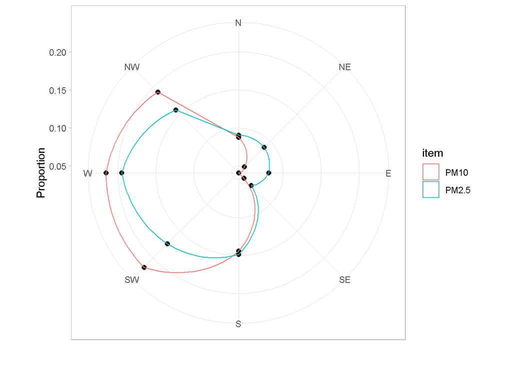

```r
#6
prop<-full_join(prop_PM10,prop_PM2.5)

ggplot(prop,aes(x=factor(Direct), y=Proportion))+
  geom_point(size=2)+
  geom_polygon(aes(group=item,colour=item),fill=NA)+
  coord_polar(start=-pi/8)+
  labs(x="", y="Proportion")+
  theme_light()
```

5번에서 만든 데이터를 합쳐, 각 item 별로 방위의 비율을 나타낸 하나의 데이터프레임을 만든다. 이 데이터프레임에 ggplot + geom_point + geom_polygon + coord_polar을 이용하면 주어진 그림을 만들 수 있다.

## [문제 3] 위 과정을 보완하는 방법 제시, 그 근거 서술

위 그림에서 서풍 계열의 영향이 크다는 것을 확인하였는데, 정확히 NW, W, SW 중 어느 방위 방향이 제일 영향력이 큰지에 대해서도 확인해볼 필요가 있을 것 같다. 그 이유는 보통 일반인들이 생각하는 북서풍으로 인한 중국 사막과 공장발 미세먼지만을 생각하는데, SW 남서 방향도 NW와 견줄 정도로 영향력이 컸기 때문이다(오히려 그래프 상에는 SW가 NW보다 더 큰 값을 보였다). 실제로 2019~2020년 中 듀크쿤샨대 연구팀 분석결과에 따르면(동아사이언스 인용, http://dongascience.donga.com/news.php?idx=33474) 미세먼지 농도에 가장 큰 영향을 주는 바람의 방향으로는 남서풍이 지목됐다. 이는 중국 내 주요 공업 단지가 몰려 있어 기존에 우리나라의 미세먼지 농도에 가장 큰 영향을 줄 것으로 생각됐던 이른바 ‘징진지’(Jingjinji) 지역(베이징, 텐진, 허베이)과 사막이 몰려 있어 황사 근원지로 꼽히는 내몽고 쪽에서 불어오는 ’북서풍’이 중국발 미세먼지의 원인이 아니라는 뜻이다. 따라서 북서풍과 남서풍 어느 것이 더 우리나라의 미세먼지 발생량에 영향을 주는지를 알아보는 것은 흥미로운 주제일 것이다. 이에 대하여 두 모집단의 평균 차이를 검정하는 t-test를 NW, SW에 대하여 모든 종류의 오염물질에 대하여 검정하여 NW와 SW 영향력의 차이가 유의하게 다른지 검정할 수 있을 것이다. 또한 연구팀에 따르면 미세먼지의 중국발 영향은 여름·겨울·봄·가을 순 영향으로 크다고 한다. 따라서 앞서 한 분석을 계절에 따라 grouping하여 분석한다면 연구팀의 결과를 검증해볼 수 있어 본 연구에 더 의미를 부여할 수 있을 것이다.

### Step 3

## [문제 1] 재현, PM2.5와 PM10에 대하여 상관계수, 결정계수의 값?

```r
##1##
#filtering
step3<-step1%>%
  filter(!is.na(Temper),!is.na(PM10),!is.na(PM2.5))%>%
  filter(month(parse_datetime(`Measurement date`)) %in% c(12,1,2))%>%
  filter(hour(parse_datetime(`Measurement date`)) %in% c(3:9))
```

filter 함수를 통해 문제 조건에 맞는 열만 추출된 dataframe step3를 만들었다.

```r
##2##
#add hour columns for summarising statistics by hour
step3_hour<-step3%>%
    mutate(Hour=hour(parse_datetime(`Measurement date`)))
#group by hour, district, and summarise mean and sd of pollutants
stat<-step3_hour%>%
  group_by(Hour,District)%>%
  summarise(
    meanT=mean(Temper),
    sdT=sd(Temper),
    mean10=mean(PM10),
    sd10=sd(PM10),
    mean2.5=mean(PM2.5),
    sd2.5=sd(PM2.5)
  )
names(stat)
```

```
## [1] "Hour"     "District" "meanT"    "sdT"      "mean10"   "sd10"     "mean2.5"
## [8] "sd2.5"
```

시간대별, 지역별 Temper, PM10, PM2.5의 평균과 분산을 구하기 위해, 우선 step3 데이터프레임의 Measurement.date를 이용하여 hour 변수를 생성하고, group_by를 hour과 district에 대하여 수행하고 summarise를 이용해 각 변수의 mean과 sd를 계산, 6개의 서로 다른 변수(meanT, sdT, mean10, sd10, mean2.5, sd2.5)에 저장하였다.

```r
##3##
#join two dataframes we've just made above.
step3_stat<-full_join(step3_hour,stat,by=c("Hour","District"))
#standardize pollutants' average value.
step3_stan<-step3_stat%>%
  mutate(Temper=(Temper-meanT)/(sdT),PM10=(PM10-mean10)/(sd10),
         PM2.5=(PM2.5-mean2.5)/(sd2.5))%>%
  dplyr::select(`Measurement date`:Speed)

#substitute original data to standardized data.
step3<-step3_stan
head(step3)
```

```
##   Measurement date   District  CO   NO2    O3      PM10     PM2.5   SO2
## 1 2017-01-01 03:00 Gangnam-gu 0.7 0.034 0.002 1.2949790 0.5879986 0.004
## 2 2017-01-01 04:00 Gangnam-gu 0.7 0.031 0.002 1.0629570 0.3639039 0.004
## 3 2017-01-01 05:00 Gangnam-gu 0.8 0.032 0.002 0.6924053 0.9165653 0.005
## 4 2017-01-01 06:00 Gangnam-gu 0.7 0.030 0.002 0.6285361 1.1440767 0.004
## 5 2017-01-01 07:00 Gangnam-gu 0.7 0.030 0.001 0.4229771 0.9146025 0.004
## 6 2017-01-01 08:00 Gangnam-gu 0.8 0.031 0.002 0.3561687 0.5443510 0.004
##      Temper Direct Speed
## 1 0.4096004   66.0   1.5
## 2 0.4996855   63.4   0.5
## 3 0.5276652   63.2   0.8
## 4 0.4468751   68.5   1.6
## 5 0.5111716   78.6   0.5
## 6 0.5606141   67.8   1.1
```

문제 2에서 구한 평균과 표준편차 데이터를 step3에 hour 열이 추가된 step3_hour에 대하여 full_join하면 각 열은 그것의 hour과 district에 해당하는 Temper, PM2.5, PM10의 평균과 표준편차 값을 포함하게 된다. 따라서 mutate를 통해 이 값들을 통해 standardize를 쉽게 할 수 있고, 기존 데이터와 같은 형식을 취하기 위해 필요한 열만 select 함수로 뽑은 뒤 이 데이터를 기존의 step3에 새로 저장하였다.

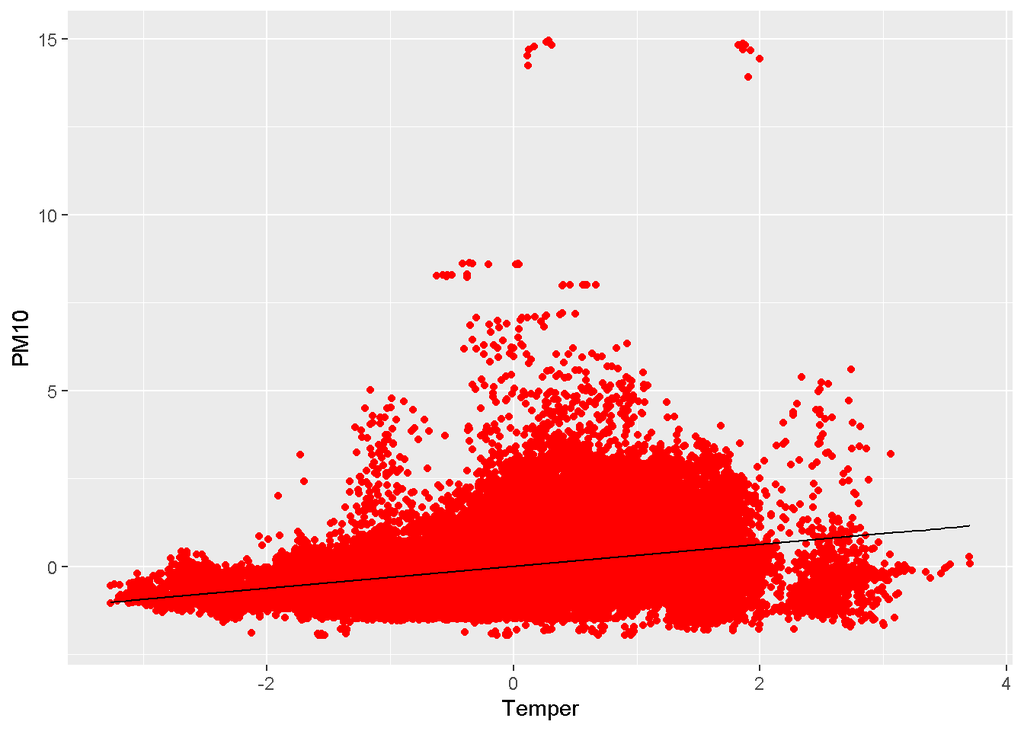

```r
##4##
fit_PM10<-lm(PM10~Temper, step3)
grid<-step3%>%
  data_grid(Temper)
grid <- grid %>%
  modelr::add_predictions(fit_PM10)

ggplot(step3, aes(x=Temper)) +
  geom_point(aes(y = PM10),colour="red") +
  geom_line(aes(y = pred), data = grid)
```

```r
#step3%>%
##  ggplot(aes(x=Temper,y=PM10))+
#  geom_point(colour="Red") +
#  stat_smooth(method = 'lm')


summary(fit_PM10)
```

```
##
## Call:
## lm(formula = PM10 ~ Temper, data = step3)
##
## Residuals:
##     Min      1Q  Median      3Q     Max
## -2.6025 -0.5540 -0.1523  0.3284 14.8571
##
## Coefficients:
##               Estimate Std. Error t value Pr(>|t|)
## (Intercept) -3.970e-17  4.374e-03    0.00        1
## Temper       3.120e-01  4.382e-03   71.21   <2e-16 ***
## ---
## Signif. codes:  0 '***' 0.001 '**' 0.01 '*' 0.05 '.' 0.1 ' ' 1
##
## Residual standard error: 0.9483 on 47010 degrees of freedom
## Multiple R-squared:  0.09736,    Adjusted R-squared:  0.09734
## F-statistic:  5071 on 1 and 47010 DF,  p-value: < 2.2e-16
```

```r
#Multiple R-squared:  0.09736,  Adjusted R-squared:  0.09734
cor(step3$PM10,step3$Temper)
```

```
## [1] 0.3120248
```

```r
#correlation coeff: 0.3120
```

```r
##5##


#step3%>%
#  ggplot(aes(x=Temper,y=PM2.5))+
#  geom_point(colour="Blue") +
#  stat_smooth(method = 'lm')

fit_PM2.5<-lm(PM2.5~Temper, step3)
summary(fit_PM2.5)
```

```
##
## Call:
## lm(formula = PM2.5 ~ Temper, data = step3)
##
## Residuals:
##     Min      1Q  Median      3Q     Max
## -2.5735 -0.5586 -0.1779  0.3517 16.0132
##
## Coefficients:
##               Estimate Std. Error t value Pr(>|t|)
## (Intercept) -1.033e-16  4.247e-03    0.00        1
## Temper       3.857e-01  4.255e-03   90.64   <2e-16 ***
## ---
## Signif. codes:  0 '***' 0.001 '**' 0.01 '*' 0.05 '.' 0.1 ' ' 1
##
## Residual standard error: 0.9209 on 47010 degrees of freedom
## Multiple R-squared:  0.1488, Adjusted R-squared:  0.1487
## F-statistic:  8216 on 1 and 47010 DF,  p-value: < 2.2e-16
```

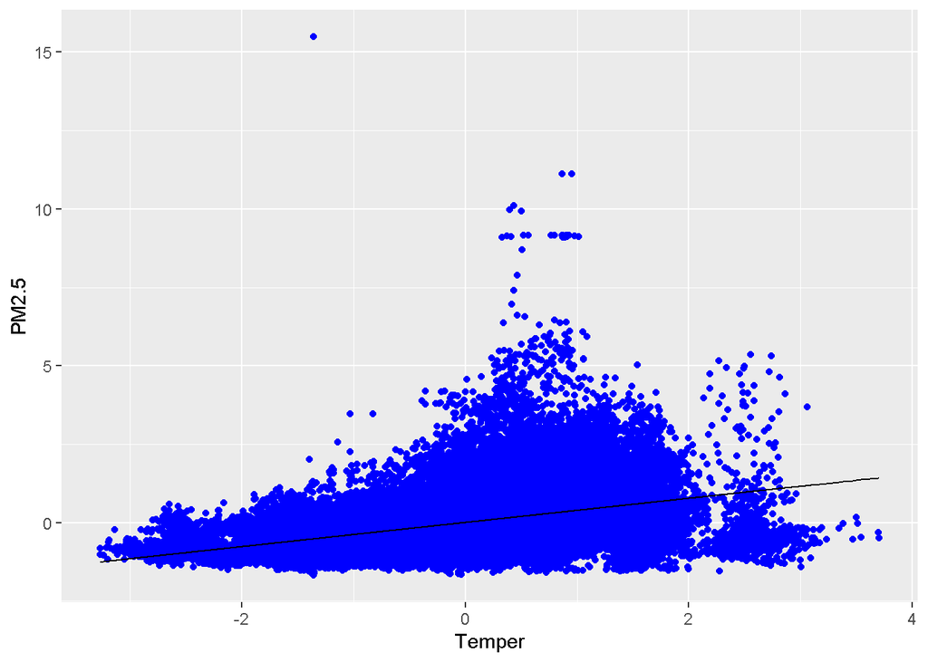

```r
fit_PM2.5<-lm(PM2.5~Temper, step3)
grid<-step3%>%
  data_grid(Temper)
grid <- grid %>%
  modelr::add_predictions(fit_PM2.5)

ggplot(step3, aes(x=Temper)) +
  geom_point(aes(y = PM2.5),colour="blue") +
  geom_line(aes(y = pred), data = grid)
```

```r
#Multiple R-squared:  0.1488,   Adjusted R-squared:  0.1487
cor(step3$PM2.5,step3$Temper)
```

```
## [1] 0.3857018
```

```r
#correlation coeff: 0.3857
```

다시 한번 각 문제의 풀이를 정리하면, 1번은 원래 데이터프레임(step3)의 filter를 이용해 간단히 구할 수 있다.

2번은 기존 데이터에 hour 변수를 추가한 데이터 프레임을 만든 뒤(step3_hour), 이것에 대해 group_by를 hour과 district 2가지 변수에 대해 적용, summarise 함수로 Temp, PM10, PM2.5의 평균과 표준편차 값을 구하였다.

3번은 2번에서 구한 값들을 하나의 데이터프레임(stat)으로 저장, 이것을 step3_hour에 대하여 key= hour과 district으로 하여 join하고, mutate를 통해 각 Temper, PM10, PM2.5에 그것들의 각 시간대, 지역별로 구해진 평균과 표준편차를 이용해 표준화 작업을 한다. 표준화된 데이터 프레임 step3_stan을 기존의 데이터 프레임에 뒤집어 씌워 최종적으로 step3는 표준화된 데이터프레임이 되었다.

4번은 lm fit에 grid에 대한 prediction 값을 저장하고 이를 ggplot + geom_point + geom_line으로 산점도와 회귀선을 그릴 수 있으며 문제 요구 사항으로 geom_point의 color=“Red”로 한다. 그 외에 ggplot 옵션은 기본 설정을 따른다. 상관계수와 결정계수를 구하려면 각각 cor(), summary(lm())을 실행해주면 된다. 상관계수는 0.3120으로 낮게 나타났고, R-squared 값은 0.09736(Multiple), 0.09734(Adjusted)로 나타났다.

5번은 4번과 마찬가지로 하되, 변수를 PM2.5로 바꾸고 color=“Blue”로 하여 진행하면 되므로 결과만 요약하면 상관계수는 0.3857, R-squared 값은 0.1488(Multiple), 0.1487(Adjusted)로 나타났다.

## [문제 2] [문제 1]의 결과에 대한 결론 제시, 이유 분석

문제 1에 해당하는 분석 결과, 온도라는 동일 변수에 대하여 PM10과 PM2.5를 선형 회귀 적합시켰을 때 상관계수는 각각 0.3120, 0.3857로 PM2.5가 온도에 관한 상관계수가 높았다. 그리고 결정계수는 Adjusted R-squared 값으로 비교하면 (Multiple의 경우도 같은 결과를 제시한다) 0.09734와 0.1487로 나타났다. 이 경우도 역시 PM2.5가 PM10보다 온도에 대한 선형 회귀 적합에서 결정계수가 크게 나타났다. 전반적인 결과를 종합하면 PM2.5가 PM10보다 더 온도에 관한 선형모델을 적합했을 때 설명력이 좋다고 보여진다.  
비록 회귀 모델은 PM2.5와 PM10 모두 유의하지만, 결정계수는 0.1 근방으로 매우 낮은 수준이다. 따라서 선형 모델 방법을 적합하였을 때는 온도와 PM10, PM2.5의 관계를 잘 설명하지 못한다고 보여지며 그 이유는 선형 모델은 기본적으로 두 변수간 선형성(선형 상관관계)를 바탕으로 하고 있지만 실제 사회 현상은 선형성을 띠기보다는 복잡한 사이 매개변수, 왜곡변수로 인하여 더 복잡한 모델을 요구한다. 실제로, 서울 대도시의 건물의 높이가 높다는 점과 높은 매연 발생량 등은 열섬현상과 더스트 돔 현상과 양의 상관관계가 있고 이것은 미세먼지 발생량과 온도 사이에 매개변수로 작용할 것이다. 따라서 단지 온도와 미세먼지라는 두 변수사이의 관계를 분석할 것이 아니라, 다양한 매개변수 왜곡변수 등을 회귀식에 고려하여 선형 모델을 분석하여야 할 것이다.

## [문제 3] 위 과정을 보완하는 방법 제시, 그 근거 서술

```r
summary(fit_PM10)
```

```
##
## Call:
## lm(formula = PM10 ~ Temper, data = step3)
##
## Residuals:
##     Min      1Q  Median      3Q     Max
## -2.6025 -0.5540 -0.1523  0.3284 14.8571
##
## Coefficients:
##               Estimate Std. Error t value Pr(>|t|)
## (Intercept) -3.970e-17  4.374e-03    0.00        1
## Temper       3.120e-01  4.382e-03   71.21   <2e-16 ***
## ---
## Signif. codes:  0 '***' 0.001 '**' 0.01 '*' 0.05 '.' 0.1 ' ' 1
##
## Residual standard error: 0.9483 on 47010 degrees of freedom
## Multiple R-squared:  0.09736,    Adjusted R-squared:  0.09734
## F-statistic:  5071 on 1 and 47010 DF,  p-value: < 2.2e-16
```

```r
summary(fit_PM2.5)
```

```
##
## Call:
## lm(formula = PM2.5 ~ Temper, data = step3)
##
## Residuals:
##     Min      1Q  Median      3Q     Max
## -2.5735 -0.5586 -0.1779  0.3517 16.0132
##
## Coefficients:
##               Estimate Std. Error t value Pr(>|t|)
## (Intercept) -1.033e-16  4.247e-03    0.00        1
## Temper       3.857e-01  4.255e-03   90.64   <2e-16 ***
## ---
## Signif. codes:  0 '***' 0.001 '**' 0.01 '*' 0.05 '.' 0.1 ' ' 1
##
## Residual standard error: 0.9209 on 47010 degrees of freedom
## Multiple R-squared:  0.1488, Adjusted R-squared:  0.1487
## F-statistic:  8216 on 1 and 47010 DF,  p-value: < 2.2e-16
```

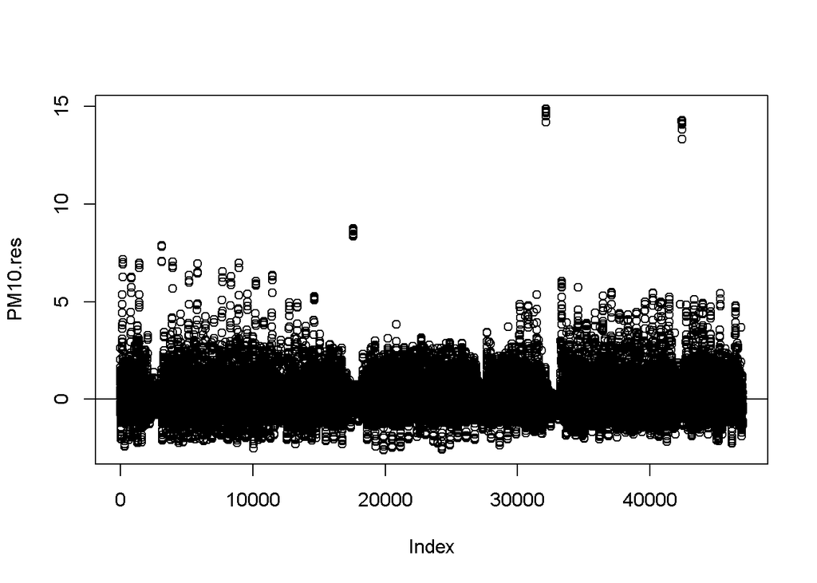

```r
PM10.res = resid(fit_PM10)
PM2.5.res = resid(fit_PM2.5)
plot(PM10.res)
abline(0,0)
```

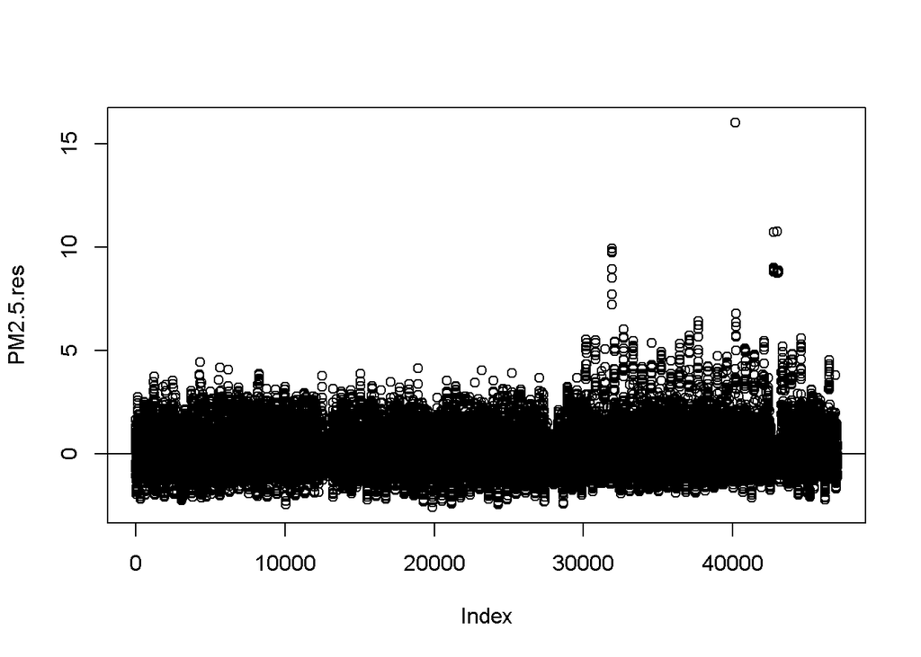

```r
plot(PM2.5.res)
abline(0,0)
```